# Project : investigate a Dataset

For this project, the aim is to conduct a data analysis and share my findings on a chosen data set.

I will follow the classic data analysis process :

- Gather the data
- Wrangle the data
- Brainstorm on some possible questions to investigate
- Explore the data
- Draw conclusions
- Communicate

The chosen dataset for this project is from [Gapfinder World](https://www.gapminder.org/data/). It represents "information about how people live their lives in different countries, tracked across the years, and on a number of different indicators".

Author : Souhail YOUSSEFI

## Step 1 : Gather the data

Chosen indicators (per country):

- Total population
- Income per person (GDP/capita, PPP dollar inflation-adjusted)
- Life expectency (years)
- Literacy rate adult (total percent of people ages 15 and above)
- Number of personal computers
- Human developpement index (Health, Education, Living standards)
- Gini coefficient (inequality, a higher number means more inequality)
- CPI (Corruption perception index, higher values mean less corruption)

*(downloaded in separate csv files)*

## Step 2 : Wrangle the data

In this part the aim is to :

- Have a quick look at each csv.
- Assess (identify problems in data quality): number of columns and rows, format, duplicates, missing values.
- Clean the csv files.
- Merge the csv files.
- Re-asses the csv files.

```python
# Import packages

import pandas as pd
import numpy as np
import matplotlib.pyplot as plt
```

### Step 2.1 : Assess data

```python
# Read csv files

population = pd.read_csv('population_total.csv')
income = pd.read_csv('income_per_person_gdppercapita_ppp_inflation_adjusted.csv')
life_expectency = pd.read_csv('life_expectancy_years.csv')
literacy = pd.read_csv('literacy_rate_adult_total_percent_of_people_ages_15_and_above.csv')
computers = pd.read_csv('personal_computers_total.csv')
human_developpement_index = pd.read_csv('hdi_human_development_index.csv')
gini = pd.read_csv('gini.csv')
cpi = pd.read_csv('corruption_perception_index_cpi.csv')

#Creates a list to be able to loop on in to check data quality
names = [population , income, life_expectency, literacy, computers, human_developpement_index, gini, cpi]

#Creates a function to get the name of each dataframe
def get_df_name(df):
    name =[x for x in globals() if globals()[x] is df][0]
    return name
```

Let's have a quick visual look at some of the csv to check if correctly showed

```python
population.head(5)
```

|  | country | 1800 | 1801 | 1802 | 1803 | 1804 | 1805 | 1806 | 1807 | 1808 | ... | 2091 | 2092 | 2093 | 2094 | 2095 | 2096 | 2097 | 2098 | 2099 | 2100 |
| --- | --- | --- | --- | --- | --- | --- | --- | --- | --- | --- | --- | --- | --- | --- | --- | --- | --- | --- | --- | --- | --- |
| 0 | Afghanistan | 3280000 | 3280000 | 3280000 | 3280000 | 3280000 | 3280000 | 3280000 | 3280000 | 3280000 | ... | 76600000 | 76400000 | 76300000 | 76100000 | 76000000 | 75800000 | 75600000 | 75400000 | 75200000 | 74900000 |
| 1 | Albania | 400000 | 402000 | 404000 | 405000 | 407000 | 409000 | 411000 | 413000 | 414000 | ... | 1330000 | 1300000 | 1270000 | 1250000 | 1220000 | 1190000 | 1170000 | 1140000 | 1110000 | 1090000 |
| 2 | Algeria | 2500000 | 2510000 | 2520000 | 2530000 | 2540000 | 2550000 | 2560000 | 2560000 | 2570000 | ... | 70400000 | 70500000 | 70500000 | 70600000 | 70700000 | 70700000 | 70700000 | 70700000 | 70700000 | 70700000 |
| 3 | Andorra | 2650 | 2650 | 2650 | 2650 | 2650 | 2650 | 2650 | 2650 | 2650 | ... | 63000 | 62900 | 62900 | 62800 | 62700 | 62700 | 62600 | 62500 | 62500 | 62400 |
| 4 | Angola | 1570000 | 1570000 | 1570000 | 1570000 | 1570000 | 1570000 | 1570000 | 1570000 | 1570000 | ... | 168000000 | 170000000 | 172000000 | 175000000 | 177000000 | 179000000 | 182000000 | 184000000 | 186000000 | 188000000 |

5 rows × 302 columns

```python
cpi.head(5)
```

|  | country | 2012 | 2013 | 2014 | 2015 | 2016 | 2017 |
| --- | --- | --- | --- | --- | --- | --- | --- |
| 0 | Afghanistan | 8.0 | 8.0 | 12.0 | 11.0 | 15.0 | 15 |
| 1 | Albania | 33.0 | 31.0 | 33.0 | 36.0 | 39.0 | 38 |
| 2 | Algeria | 34.0 | 36.0 | 36.0 | 36.0 | 34.0 | 33 |
| 3 | Angola | 22.0 | 23.0 | 19.0 | 15.0 | 18.0 | 19 |
| 4 | Argentina | 35.0 | 34.0 | 34.0 | 32.0 | 36.0 | 39 |

It seems like research have been perfomed over different number of countries and durations for each indicator.

```python
# Check sizes

for name in names :
    print(get_df_name(name)
          +" contains "
          +str(name.shape[0])
          +" countries monitored for "
          +str(name.shape[1])
          +" years.")
```

```
population contains 195 countries monitored for 302 years.
income contains 193 countries monitored for 242 years.
life_expectency contains 187 countries monitored for 302 years.
literacy contains 150 countries monitored for 38 years.
computers contains 183 countries monitored for 18 years.
human_developpement_index contains 188 countries monitored for 30 years.
gini contains 195 countries monitored for 242 years.
cpi contains 177 countries monitored for 7 years.
```

The dataframes have different sizes. We will have to work on this later.

```python
# Check formats

for name in names :
    print(get_df_name(name)+" format\n")
    name.info()
    print("\n-----------------\n")
```

```
population format

<class 'pandas.core.frame.DataFrame'>
RangeIndex: 195 entries, 0 to 194
Columns: 302 entries, country to 2100
dtypes: int64(301), object(1)
memory usage: 460.2+ KB

-----------------

income format

<class 'pandas.core.frame.DataFrame'>
RangeIndex: 193 entries, 0 to 192
Columns: 242 entries, country to 2040
dtypes: int64(241), object(1)
memory usage: 365.0+ KB

-----------------

life_expectency format

<class 'pandas.core.frame.DataFrame'>
RangeIndex: 187 entries, 0 to 186
Columns: 302 entries, country to 2100
dtypes: float64(301), object(1)
memory usage: 441.3+ KB

-----------------

literacy format

<class 'pandas.core.frame.DataFrame'>
RangeIndex: 150 entries, 0 to 149
Data columns (total 38 columns):
 #   Column   Non-Null Count  Dtype
---  ------   --------------  -----
 0   country  150 non-null    object
 1   1975     6 non-null      float64
 2   1976     7 non-null      float64
```

[output cut: 125 more lines]

```
RangeIndex: 177 entries, 0 to 176
Data columns (total 7 columns):
 #   Column   Non-Null Count  Dtype
---  ------   --------------  -----
 0   country  177 non-null    object
 1   2012     172 non-null    float64
 2   2013     173 non-null    float64
 3   2014     171 non-null    float64
 4   2015     165 non-null    float64
 5   2016     173 non-null    float64
 6   2017     177 non-null    int64
dtypes: float64(5), int64(1), object(1)
memory usage: 9.8+ KB

-----------------
```

All csv contain one row dedicated to countries in string format and the indicator following each year either in int or float. It might be interesting to use the country column as index later.

```python
# Check duplicates

for name in names :
    print(get_df_name(name)+" number of duplicates")
    if sum(name.duplicated()) == 0 :
        print("none\n-----------------")
```

```
population number of duplicates
none
-----------------
income number of duplicates
none
-----------------
life_expectency number of duplicates
none
-----------------
literacy number of duplicates
none
-----------------
computers number of duplicates
none
-----------------
human_developpement_index number of duplicates
none
-----------------
gini number of duplicates
none
-----------------
cpi number of duplicates
none
-----------------
```

There is no dupplicates to drop in the files

### Step 2.2 : Reorganize the data

At the end it should look like this : {Country, Year, Indicator 1 Value, Indicator 2 Value, … }.

To deal with this, for every metric we will do the following :

- Create a new dataframe with country, year and indicator name
- Fill for every year the indicator value for all the countries *(for exemple all population values for 1800 in all countries, then the next loop would append this with all population values for 1801 in all countries and so on until the end.*
- Store each new edited file in order to merge them all afterwards

```python
for name in names :
    labels = np.array(['country', 'year', get_df_name(name)])
    df = pd.DataFrame(columns = labels)
    years = name.iloc[:,1:].columns.values
    for year in years:
        df2 = name[['country', year]].copy()
        df2.rename(columns={year:get_df_name(name)}, inplace=True)
        df2.insert(1, 'year', year)
        df = df.append(df2)

    file_name = get_df_name(name)+'_edited.csv'
    df.to_csv(file_name, index=False)

population_new = pd.read_csv('population_edited.csv')
print(population_new.shape)
population_new.head()
```

```
(58695, 3)
```

|  | country | year | population |
| --- | --- | --- | --- |
| 0 | Afghanistan | 1800 | 3280000 |
| 1 | Albania | 1800 | 400000 |
| 2 | Algeria | 1800 | 2500000 |
| 3 | Andorra | 1800 | 2650 |
| 4 | Angola | 1800 | 1570000 |

### Step 2.3 : Merge the data

```python
# Upload the new edited csv files

population = pd.read_csv('population_edited.csv')
income = pd.read_csv('income_edited.csv')
life_expectency = pd.read_csv('life_expectency_edited.csv')
literacy = pd.read_csv('literacy_edited.csv')
computers = pd.read_csv('computers_edited.csv')
human_developpement_index = pd.read_csv('human_developpement_index_edited.csv')
gini = pd.read_csv('gini_edited.csv')
cpi = pd.read_csv('cpi_edited.csv')

names_edited = [population , income, life_expectency, literacy, computers, human_developpement_index, gini, cpi]
```

```python
# Merging population and cpi for test
df3 = pd.read_csv('population_edited.csv')
df3.tail()
df4 = pd.read_csv('cpi_edited.csv')
df4.tail()
df5 = pd.merge(df3, df4, how='outer', on=['country','year'])


print('Last row of merged dataframe is '+str(df5.shape[0]-1))
print('Last row of biggest dataframe non merged is '+str(df3.shape[0]-1))
print('\n')
print('Merged dataframe')
print(df5.query('country=="Afghanistan"').query('year=="2012"'))
print('\n')
print('Population dataframe')
print(df3.query('country=="Afghanistan"').query('year=="2012"'))
print('\n')
print('Cpi dataframe')
print(df4.query('country=="Afghanistan"').query('year=="2012"'))
```

```
Last row of merged dataframe is 58694
Last row of biggest dataframe non merged is 58694


Merged dataframe
           country  year  population  cpi
41340  Afghanistan  2012    31200000  8.0


Population dataframe
           country  year  population
41340  Afghanistan  2012    31200000


Cpi dataframe
       country  year  cpi
0  Afghanistan  2012  8.0
```

Merging test seems to work. We manage to find population and cpi information in the new one. Let's do it for all the datasets now.

```python
final_df = population
#Let's add regions for more insight
regions = pd.read_csv('data_geographies.csv', sep=';')
regions.rename(columns={"four_regions":"regions"}, inplace=True)
regions.rename(columns={"name":"country"}, inplace=True)
final_df = pd.merge(final_df, regions, how='outer', on=['country'])

for name in names_edited[1:] : #start from income as population dataset is already in final_df
     final_df = pd.merge(final_df, name, how='outer', on=['country','year'])

# Check 1 : visually for number of columns
final_df.head()
```

|  | country | year | population | regions | income | life_expectency | literacy | computers | human_developpement_index | gini | cpi |
| --- | --- | --- | --- | --- | --- | --- | --- | --- | --- | --- | --- |
| 0 | Afghanistan | 1800.0 | 3280000.0 | asia | 603.0 | 28.2 | NaN | NaN | NaN | 30.5 | NaN |
| 1 | Afghanistan | 1801.0 | 3280000.0 | asia | 603.0 | 28.2 | NaN | NaN | NaN | 30.5 | NaN |
| 2 | Afghanistan | 1802.0 | 3280000.0 | asia | 603.0 | 28.2 | NaN | NaN | NaN | 30.5 | NaN |
| 3 | Afghanistan | 1803.0 | 3280000.0 | asia | 603.0 | 28.2 | NaN | NaN | NaN | 30.5 | NaN |
| 4 | Afghanistan | 1804.0 | 3280000.0 | asia | 603.0 | 28.2 | NaN | NaN | NaN | 30.5 | NaN |

```python
# Check 2 : visually for number of rows
# Biggest non merged datafram was 58694 lines (195 countries x 301 years)
final_df.tail()
```

|  | country | year | population | regions | income | life_expectency | literacy | computers | human_developpement_index | gini | cpi |
| --- | --- | --- | --- | --- | --- | --- | --- | --- | --- | --- | --- |
| 58694 | Zimbabwe | 2100.0 | 31000000.0 | africa | NaN | 75.7 | NaN | NaN | NaN | NaN | NaN |
| 58695 | Hong Kong, China | NaN | NaN | asia | NaN | NaN | NaN | NaN | NaN | NaN | NaN |
| 58696 | Macedonia, FYR | NaN | NaN | europe | NaN | NaN | NaN | NaN | NaN | NaN | NaN |
| 58697 | Swaziland | NaN | NaN | africa | NaN | NaN | NaN | NaN | NaN | NaN | NaN |
| 58698 | Taiwan | NaN | NaN | asia | NaN | NaN | NaN | NaN | NaN | NaN | NaN |

Let's get rid of the countries with no info at the end

```python
final_df=final_df.iloc[:58695,:]
final_df.tail()
```

|  | country | year | population | regions | income | life_expectency | literacy | computers | human_developpement_index | gini | cpi |
| --- | --- | --- | --- | --- | --- | --- | --- | --- | --- | --- | --- |
| 58690 | Zimbabwe | 2096.0 | 30900000.0 | africa | NaN | 75.1 | NaN | NaN | NaN | NaN | NaN |
| 58691 | Zimbabwe | 2097.0 | 31000000.0 | africa | NaN | 75.3 | NaN | NaN | NaN | NaN | NaN |
| 58692 | Zimbabwe | 2098.0 | 31000000.0 | africa | NaN | 75.4 | NaN | NaN | NaN | NaN | NaN |
| 58693 | Zimbabwe | 2099.0 | 31000000.0 | africa | NaN | 75.5 | NaN | NaN | NaN | NaN | NaN |
| 58694 | Zimbabwe | 2100.0 | 31000000.0 | africa | NaN | 75.7 | NaN | NaN | NaN | NaN | NaN |

```python
# Check 3 : check one line with all values to confirm that the merge is correct
print('Merged dataframe')
print(final_df.query('country=="France"').query('year=="2015"'))
```

```
Merged dataframe
      country    year  population regions   income  life_expectency  literacy  \
18275  France  2015.0  64500000.0  europe  37800.0             82.5       NaN

       computers  human_developpement_index  gini   cpi
18275        NaN                      0.888  32.6  70.0
```

```python
for name in names_edited:
    print(name.query('country=="France"').query('year=="2015"')[get_df_name(name)].values)
```

```
[64500000]
[37800]
[82.5]
[]
[]
[0.888]
[32.6]
[70.]
```

Seems like it's working !

```python
final_df.to_csv('global_data.csv', index=False)
```

## Step 3 : Exploratory Data Analysis

In this part the aim is to make visualisation of the gathered and cleaned data to bring answers to the introduction question.

### Research question 1 : How is income distributed in the world in 2020 compared to 1950?

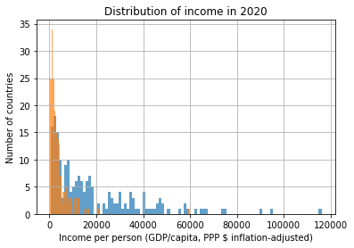

```python
#Calculate and plot income distribution for 2020 and 1950
fig = plt.figure()
final_df.query('year == "2020"').income.hist(bins=100, alpha=0.7)
final_df.query('year == "1950"').income.hist(bins=100, alpha=0.7)
plt.title('Distribution of income in 2020')
plt.xlabel('Income per person (GDP/capita, PPP $ inflation-adjusted)')
plt.ylabel('Number of countries');
```

#### Partial conclusion 1 :

- Income doesn't have the same distribution in 2020 compared to 1950
- Income in 1950 is less spread and more skewed to the right compared to 2020 : this means that inequalities between countries increased through time.
- Generally countries have increased their income per person compared to 1950

### Research question 2 : How did life expectency change through time for each region ?

```python
years = final_df['year'].unique()
regions_name = final_df['regions'].unique()
life_expectency = pd.DataFrame(years, columns=['year'])

#Calculate mean life expectency per year and per region
for region in regions_name :
    life_expectency_per_region = pd.DataFrame(columns=['year', region])
    for year in years :
        mean = int(final_df.query('year == @year').query('regions == @region').life_expectency.mean())
        new_row = pd.DataFrame({'year': [year], region:[mean]})
        life_expectency_per_region = life_expectency_per_region.append(new_row, ignore_index=True)
    life_expectency = pd.merge(life_expectency, life_expectency_per_region, how='outer', on=['year'])

#convert years from float to int
life_expectency['year'] = life_expectency['year'].astype(int)
life_expectency=life_expectency.set_index('year')

life_expectency.head()
```

| year | asia | europe | africa | americas |
| --- | --- | --- | --- | --- |
| 1800 | 29 | 35 | 30 | 31 |
| 1801 | 29 | 35 | 30 | 31 |
| 1802 | 29 | 35 | 30 | 31 |
| 1803 | 29 | 34 | 30 | 31 |
| 1804 | 29 | 35 | 30 | 31 |

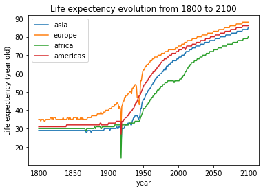

```python
life_expectency.plot(kind='line');
plt.title('Life expectency evolution from 1800 to 2100')
plt.xlabel('year')
plt.ylabel('Life expectency (year old)');
```

Let's use moving average to smooth out the curves and allow us to observe the long term trend.

```python
moving_avg_life_expectency = life_expectency

for region in life_expectency.columns.values :
    for year in range (int(life_expectency.index[4]),int(life_expectency.index[-1])):
        moving_avg_life_expectency.loc[year, region] = (life_expectency.loc[year,region]+
                                                        life_expectency.loc[year-1,region]+
                                                        life_expectency.loc[year-2,region]+
                                                        life_expectency.loc[year-3,region]+
                                                        life_expectency.loc[year-4,region])/5
```

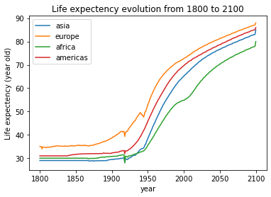

```python
moving_avg_life_expectency.plot(kind='line');
plt.title('Life expectency evolution from 1800 to 2100')
plt.xlabel('year')
plt.ylabel('Life expectency (year old)');
```

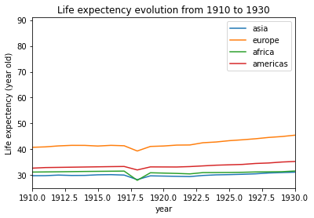

```python
moving_avg_life_expectency.plot(kind='line');
plt.xlim(1910,1930)
plt.title('Life expectency evolution from 1910 to 1930')
plt.xlabel('year')
plt.ylabel('Life expectency (year old)');
```

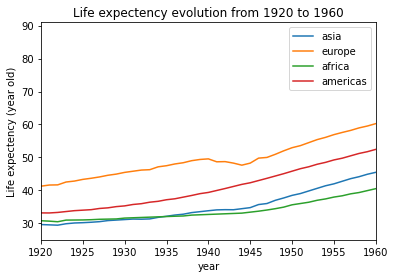

```python
moving_avg_life_expectency.plot(kind='line');
plt.xlim(1920,1960)
plt.title('Life expectency evolution from 1920 to 1960')
plt.xlabel('year')
plt.ylabel('Life expectency (year old)');
```

### Research question 3 : Do countries with higher income achieve higher human developpement index ?

Income have been monitored for longer period than human developpement index (hdi) and over more countries. Let's only keep the years and countries where both have been monitored. Let's therefore check head and tail of hdi dataframe.

```python
human_developpement_index.head(1)
```

|  | country | year | human_developpement_index |
| --- | --- | --- | --- |
| 0 | Afghanistan | 1990 | 0.298 |

```python
human_developpement_index.tail(2)
```

|  | country | year | human_developpement_index |
| --- | --- | --- | --- |
| 5450 | Zambia | 2018 | 0.591 |
| 5451 | Zimbabwe | 2018 | 0.563 |

So we will perfom this study from 1990 to 2018 for hdi's 188 countries.

```python
df_question_3 = final_df.query('year >= 1990 & year <= 2018')

#calculate mean income and hdi per country from 1990 to 2018
country_name = human_developpement_index['country'].unique()
df_question_3_countries = pd.DataFrame(columns=['country','income','hdi'])
for country in country_name :
    mean_income_per_country = df_question_3.query('country == @country').income.mean()
    mean_hdi_per_country = df_question_3.query('country == @country').human_developpement_index.mean()
    new_row = pd.DataFrame({'country': [country], 'income': [mean_income_per_country],'hdi': [mean_hdi_per_country]})
    #make sure to do df= df.append()
    df_question_3_countries = df_question_3_countries.append(new_row, ignore_index=True)

df_question_3_countries.head()
```

|  | country | income | hdi |
| --- | --- | --- | --- |
| 0 | Afghanistan | 1294.000000 | 0.398310 |
| 1 | Albania | 7304.482759 | 0.699862 |
| 2 | Algeria | 11588.620690 | 0.676552 |
| 3 | Andorra | 36689.655172 | 0.826632 |
| 4 | Angola | 5061.034483 | 0.491650 |

```python
#Let's calculate the median income for the countries
median_income = df_question_3_countries.income.median()
print(median_income)
```

```
8515.51724137931
```

```python
#Let's calculate mean hdi from countries under median
hdi_low_income = df_question_3_countries.query('income < @median_income').hdi.mean()

#Let's calculate mean hdi from countries over median
hdi_high_income = df_question_3_countries.query('income >= @median_income').hdi.mean()
```

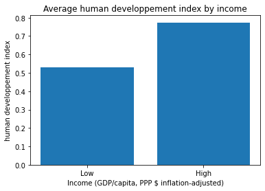

```python
locations = [1, 2]
heights = [hdi_low_income, hdi_high_income]
labels = ['Low', 'High']
plt.bar(locations, heights, tick_label=labels)
plt.title('Average human developpement index by income')
plt.xlabel('Income (GDP/capita, PPP $ inflation-adjusted)')
plt.ylabel('human developpement index');
```

#### Partial conclusion 3 :

- The answer seems to be yes. Human developpement index is on average higher for higher incomes than lower incomes.
- Median income is 8515 GDP/Capita, PPP dollar inflation-adjusted
- It could makes sens since human developpement index is based on three dimensions (health level, educational level and living standard) which are all in some sort of way related to income.

Gini coefficient have been monitored for in 195 countries. Corruption index have been monitored for in 177 countries . Let's only keep the years and countries where both have been monitored. Let's keep CPI's countries.

```python
cpi.tail()
```

|  | country | year | cpi |
| --- | --- | --- | --- |
| 1057 | Venezuela | 2017 | 18.0 |
| 1058 | Vietnam | 2017 | 35.0 |
| 1059 | Yemen | 2017 | 16.0 |
| 1060 | Zambia | 2017 | 37.0 |
| 1061 | Zimbabwe | 2017 | 22.0 |

```python
df_question_4 = final_df.query('year == "2017"')
cpi_2017 = cpi.query('year == "2017"')

df_question_4 = pd.merge(df_question_4, cpi, how='inner', on=['country','year','cpi'])
```

```python
df_question_4.head()
```

|  | country | year | population | regions | income | life_expectency | literacy | computers | human_developpement_index | gini | cpi |
| --- | --- | --- | --- | --- | --- | --- | --- | --- | --- | --- | --- |
| 0 | Afghanistan | 2017.0 | 36300000.0 | asia | 1760.0 | 63.4 | NaN | NaN | 0.493 | 36.8 | 15.0 |
| 1 | Albania | 2017.0 | 2880000.0 | europe | 11800.0 | 78.2 | NaN | NaN | 0.789 | 29.0 | 38.0 |
| 2 | Algeria | 2017.0 | 41400000.0 | africa | 13900.0 | 77.7 | NaN | NaN | 0.758 | 27.6 | 33.0 |
| 3 | Angola | 2017.0 | 29800000.0 | africa | 6050.0 | 64.2 | NaN | NaN | 0.576 | 42.6 | 19.0 |
| 4 | Argentina | 2017.0 | 43900000.0 | americas | 18900.0 | 76.7 | NaN | NaN | 0.832 | 42.3 | 39.0 |

```python
df_question_4['year'].unique()
```

```
array([2017.])
```

```python
df_question_4.shape
```

```
(177, 11)
```

We end up with the right number of countries of countries for year 2017

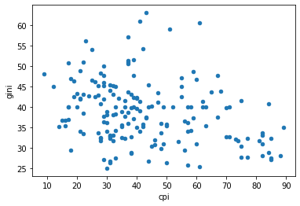

```python
# Let's plot a scatter plot for gini and cpi
df_question_4.plot(x='cpi', y='gini', kind='scatter');
```

### Research bonus : Check correlation between different metrics.

```python
df_question_4_2 = df_question_4.loc[:, ['population', 'income','life_expectency','human_developpement_index','gini','cpi']]
df_question_4_2.head()
```

|  | population | income | life_expectency | human_developpement_index | gini | cpi |
| --- | --- | --- | --- | --- | --- | --- |
| 0 | 36300000.0 | 1760.0 | 63.4 | 0.493 | 36.8 | 15.0 |
| 1 | 2880000.0 | 11800.0 | 78.2 | 0.789 | 29.0 | 38.0 |
| 2 | 41400000.0 | 13900.0 | 77.7 | 0.758 | 27.6 | 33.0 |
| 3 | 29800000.0 | 6050.0 | 64.2 | 0.576 | 42.6 | 19.0 |
| 4 | 43900000.0 | 18900.0 | 76.7 | 0.832 | 42.3 | 39.0 |

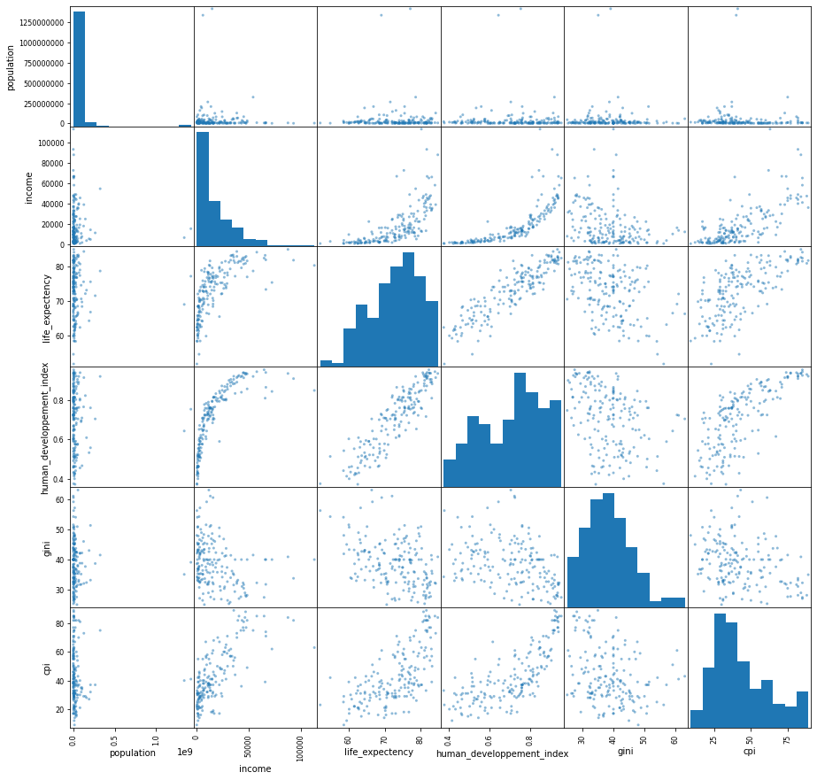

```python
pd.plotting.scatter_matrix(df_question_4_2, figsize=(15,15));
```

#### Partial conclusion "bonus" :

- There seems to be some interesting correlation between :
  - (Exponential) Income and Life expectency : rich people can afford healthier lifestyle and better healthcare ?
  - (Exponential) Income and Human developpement index : human developpement index contains three dimensions (health level, educational level and living standard) which are all in some sort of way related to income.
  - (Linear) Life expectency and Human developpement index : human developpement index contains health level and living standard dimensions which could relate to life expectency